# easy geom recipes: compute_group

## Step 4: Enjoy! Use your function

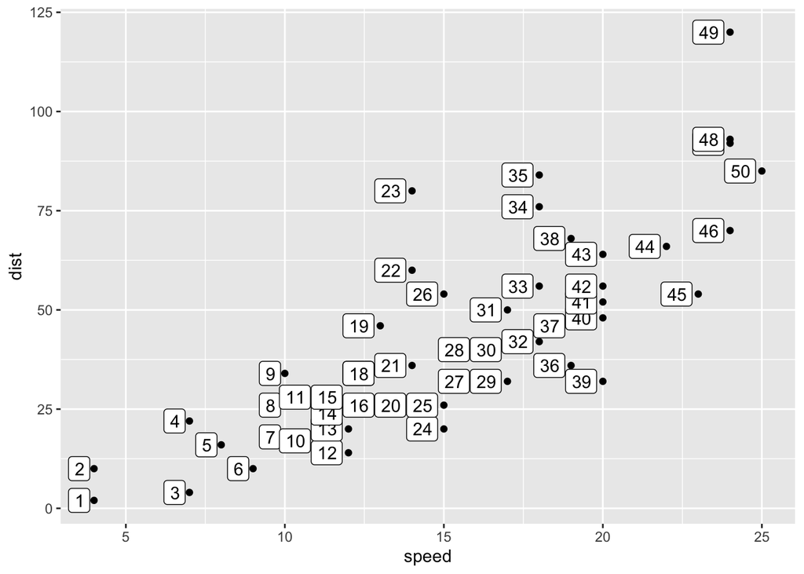

```r
cars %>%
  ggplot() +
  aes(x = speed, y = dist) +
  geom_point() +
  geom_label_row_number(hjust = 1.2) # function in action
```

### And check out conditionality!

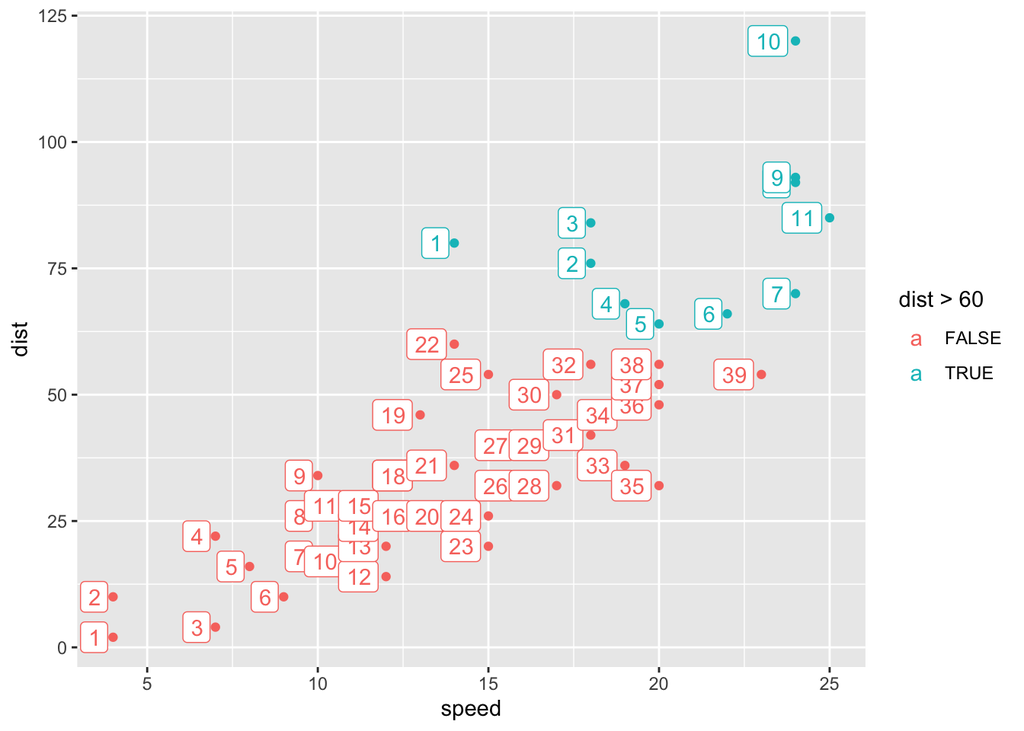

```r
last_plot() +
  aes(color = dist > 60) # Computation is within group
```

# Task #2: create `geom_text_coordinates()`

Using recipe #2 as a reference, can you create the function `geom_text_coordinates()`.

–

- geom should label point with its coordinates ‘(x, y)’
- geom should have behavior of geom_text (not geom_label)

Hint:

```r
paste0("(", 1, ", ",3., ")")
```

```
## [1] "(1, 3)"
```

```r
# step 0: use base ggplot2

# step 1: write your compute_group function (and test)

# step 2: write ggproto with compute_group as an input

# step 3: write your geom_*() function with ggproto as an input

# step 4: enjoy!
```

# Example recipe #3: `geom_point_lm_fitted()`

## Step 0: use base ggplot2 to get the job done

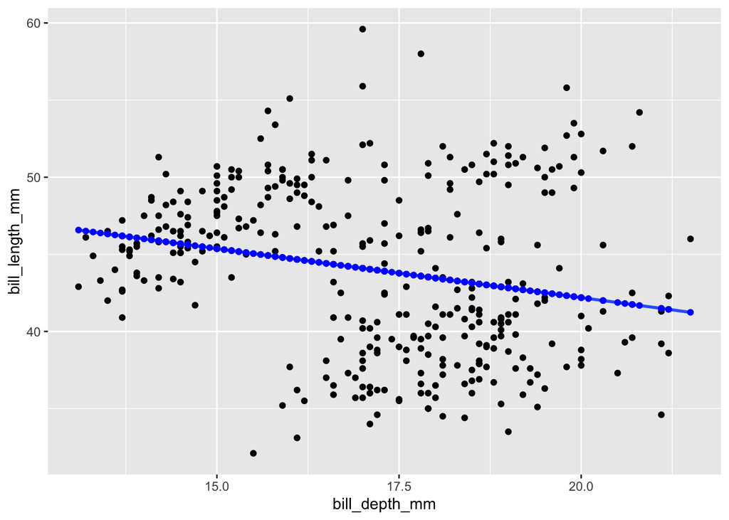

```r
model <- lm(formula = bill_length_mm ~ bill_depth_mm,
            data = penguins)

penguins_w_fitted <- penguins %>%
  mutate(fitted = model$fitted.values)


penguins %>%
  ggplot() +
  aes(x = bill_depth_mm, y = bill_length_mm) +
  geom_point() +
  geom_smooth(method = "lm", se = F) +
  geom_point(data = penguins_w_fitted,
             aes(y = fitted),
             color = "blue")
```

## Step 1: computation

```r
compute_group_lm_fitted<- function(data, scales){
  model<-lm(formula= y ~ x, data = data)
  data %>%
    mutate(y=model$fitted.values)
}

# test out the function
penguins %>%
  # rename to explicitly state the x and y inputs
  rename(x = bill_depth_mm, y = bill_length_mm)%>%
  compute_group_lm_fitted()
```

```
## # A tibble: 333 × 8
##    species island        y     x flipper_length_mm body_mass_g sex     year
##    <fct>   <fct>     <dbl> <dbl>             <int>       <int> <fct>  <int>
##  1 Adelie  Torgersen  43.0  18.7               181        3750 male    2007
##  2 Adelie  Torgersen  43.8  17.4               186        3800 female  2007
##  3 Adelie  Torgersen  43.5  18                 195        3250 female  2007
##  4 Adelie  Torgersen  42.6  19.3               193        3450 female  2007
##  5 Adelie  Torgersen  41.8  20.6               190        3650 male    2007
##  6 Adelie  Torgersen  43.6  17.8               181        3625 female  2007
##  7 Adelie  Torgersen  42.4  19.6               195        4675 male    2007
##  8 Adelie  Torgersen  43.7  17.6               182        3200 female  2007
##  9 Adelie  Torgersen  41.4  21.2               191        3800 male    2007
## 10 Adelie  Torgersen  41.5  21.1               198        4400 male    2007
## # … with 323 more rows
```

## Step 2: define ggproto

```r
StatLmFitted<-ggplot2::ggproto(`_class` = "StatLmFitted",
                                  `_inherit` = ggplot2::Stat,
                                  required_aes = c("x", "y"),
                                  compute_group = compute_group_lm_fitted)
```

## Step 3: define geom_* function

```r
geom_point_lm_fitted <- function(mapping = NULL, data = NULL,
                           position = "identity", na.rm = FALSE,
                           show.legend = NA,
                           inherit.aes = TRUE, ...) {
  ggplot2::layer(
    stat = StatLmFitted, # proto object from step 2
    geom = ggplot2::GeomPoint, # inherit other behavior
    data = data,
    mapping = mapping,
    position = position,
    show.legend = show.legend,
    inherit.aes = inherit.aes,
    params = list(na.rm = na.rm, ...)
  )
}
```

## Step 4: Enjoy! Use your function

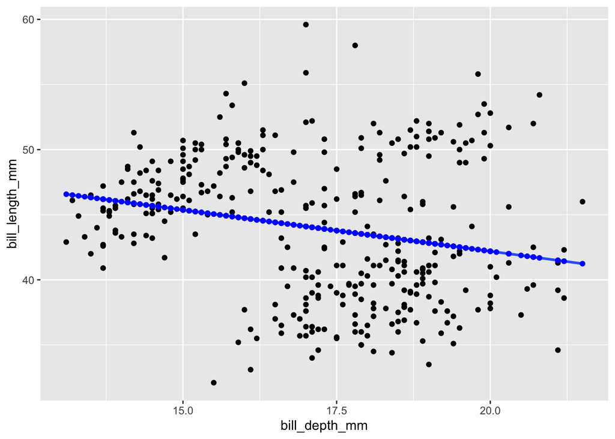

```r
penguins %>%
  ggplot() +
  aes(x = bill_depth_mm, y = bill_length_mm) +
  geom_point() +
  geom_smooth(method="lm", se= F)+
  geom_point_lm_fitted(color="blue")
```

### And check out conditionality

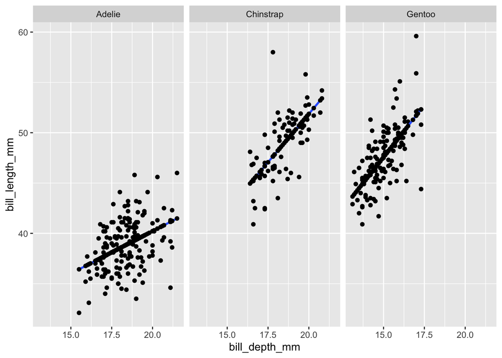

```r
penguins %>%
  ggplot() +
  aes(x = bill_depth_mm, y = bill_length_mm) +
  geom_point() +
  geom_smooth(method="lm", se= F) +
  geom_point_lm_fitted() +
  facet_wrap(facets = vars(species))
```

# Task #3 create `geom_segment_lm_residuals()`

Create the function `geom_segment_lm_residuals()`.

### Hint: consider what aesthetics are required for segments. We’ll give you Step 0 this time…

## Step 0: use base ggplot2 to get the job done

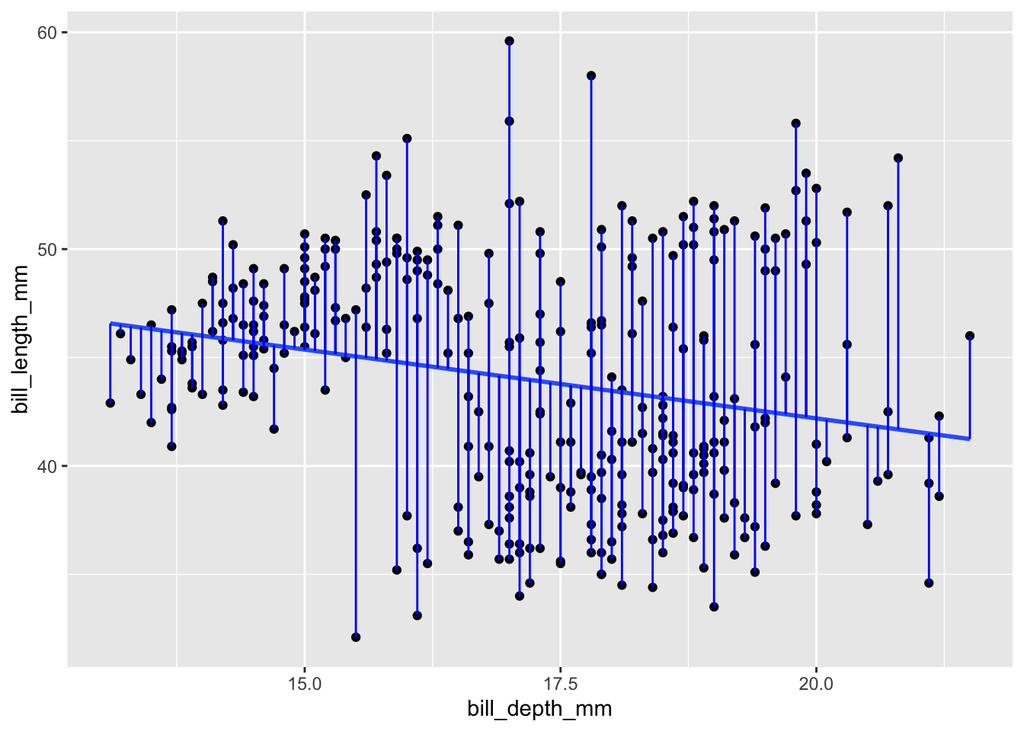

```r
# step 0: use base ggplot2
model <- lm(formula = bill_length_mm ~ bill_depth_mm,
            data = penguins)

penguins_w_fitted <- penguins %>%
  mutate(fitted = model$fitted.values)

penguins %>%
  ggplot() +
  aes(x = bill_depth_mm, y = bill_length_mm) +
  geom_point() +
  geom_smooth(method = "lm", se = F) +
  geom_segment(data = penguins_w_fitted,
             aes(yend = fitted, xend = bill_depth_mm),
             color = "blue")
```

```r
# step 1: write your compute_group function (and test)

# step 2: write ggproto with compute_group as an input

# step 3: write your geom_*() function with ggproto as an input

# step 4: enjoy!
```

Not interested in writing your own geoms?

Check out some ready-to-go geoms that might be of interest in the ggxmean package… or other extension packages.

Interested in working a bit more with geoms and making them available to more folks, but not interested in writing your own package?

Join in on the development and validation of the ggxmean package for statistical educators and everyday analysis!